# Introduction to data.tables

25. April 2016

## About me

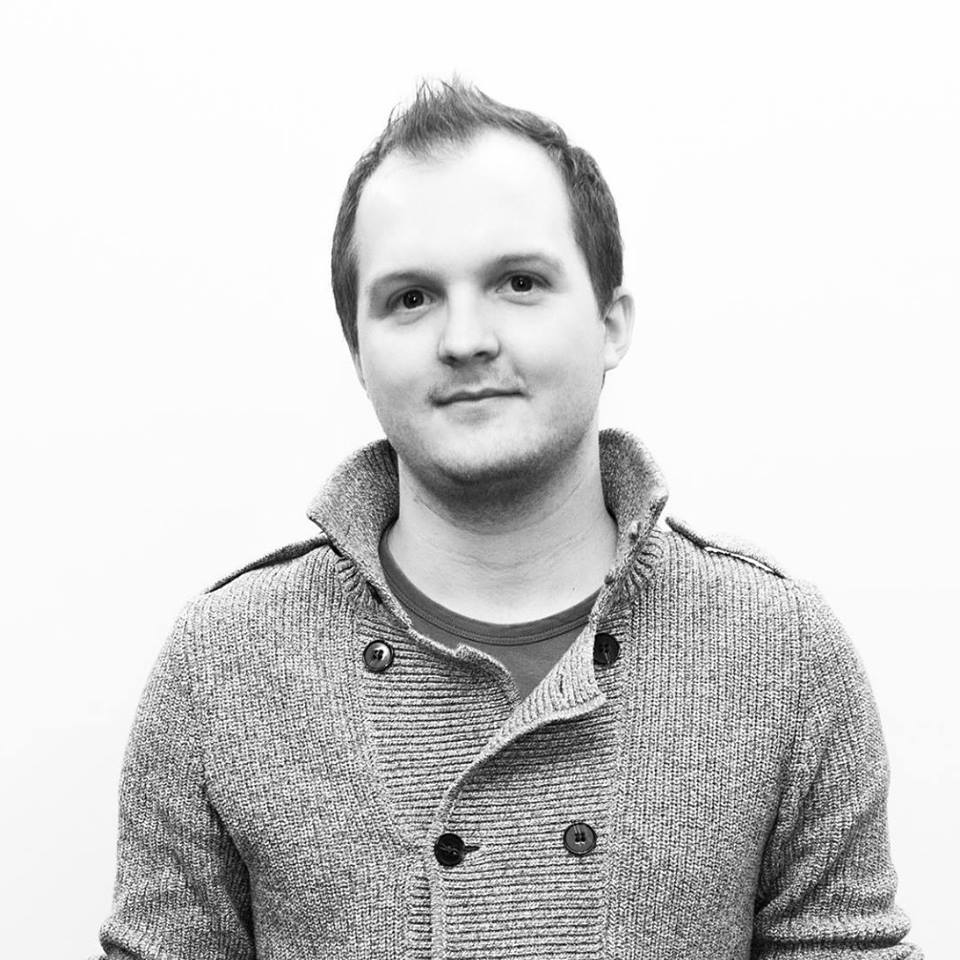

- Studied statistics at the Ludwig-Maximilians-University Munich
- Currently doing a PhD in computational statistics
- Meetups:
  - [Munich datageeks](http://munich-datageeks.de/)
  - [Applied R Munich](http://lmu-applied-r.github.io/)
- Slides:
  - https://github.com/lmu-applied-r/2016-data.table

*statistics*, *machine learning*, *R*, *boosting*, *model selection*, *optimization*, *Linux*, *ensemble methods*, *parallel programming*, *data mining*, *visualization*, *python*, *SQL*, *data science*, *predictive modelling*, …

## *data.table*

- R package by M Dowle, A Srinivasan, T Short, S Lianoglou, …
- Current version: 1.9.6 (CRAN), 1.9.7 (devel)
- Description:

  Fast aggregation of large data (e.g. 100GB in RAM), fast ordered joins, fast add/modify/delete of columns by group using no copies at all, list columns and a fast file reader (fread). Offers a natural and flexible syntax, for faster development.

```r
install.packages("data.table")
```

```r
library(data.table)
```

## What is a *data.frame*?

A data.frame is like

- a `matrix()` in which columns can have different types of data in it (integer, character, factors, etc.)
- a `list()` of vectors which all have the same length.

```r
data.frame(a = c(1,2,3,5), b = c("A", "B", "C", "D"))
```

```
##   a b
## 1 1 A
## 2 2 B
## 3 3 C
## 4 5 D
```

## And what's the thing about *data.table*?

- More efficient syntax:
  - (almost) everything can be done in square brackets `[]`
  - Fewer repititions of variable names
- Faster calculations:
  - Faster aggregation
  - Update by reference
- Less memory required (not quite true for small datasets)
- Fast import of tabular data

And one of the most important things:

```
Any R function from any R package can be used in queries not just the
subset of functions made available by a database backend
```

## *data.frame*, *data.table* and *SQL*

| Selection | *data.frame* | *data.table* | *SQL* |
| --- | --- | --- | --- |
| Rows | `DF[i, ]` | `DT[i]` | *WHERE* |
| Columns | `DF[ , j]` | `DT[, .(j)]` | *SELECT* |
| Grouping | *???* | `DT[by = ...]` | *GROUP BY* |

`data.table` offers a syntax similiar to *SQL*

## *data.tables* general form

```r
DT[  i  ,          j     , by]
DT[where, select|update|do, by]
```

```
Take rows i, calculate j and group by
```

Wait a minute, why *calculate j*? Don't we only want to select columns?

```r
data("mtcars")
mtcarsDT = data.table(mtcars)
mtcarsDT[mpg > 20,
         .(AvgHP = mean(hp),
           "MinWT(kg)" = min(wt*453.6)),
         by = .(cyl, under5gears = gear < 5)]
```

Implicit calculation of new variables, more to come…

## Example data: *mtcars*

Motor Trend Car Road Tests

A data frame with 32 observations on 11 variables.

###### [, 1] mpg Miles/(US) gallon

###### [, 2] cyl Number of cylinders

###### [, 3] disp Displacement (cu.in.)

###### [, 4] hp Gross horsepower

###### [, 5] drat Rear axle ratio

###### [, 6] wt Weight (1000 lbs)

###### [, 7] qsec 1/4 mile time

###### [, 8] vs V/S

###### [, 9] am Transmission (0 = automatic, 1 = manual)

###### [,10] gear Number of forward gears

###### [,11] carb Number of carburetors

## Let's start with *i*

- Rows 1 - 3:
  - `mtcars[1:3, ]`
  - `mtcarsDT[1:3]`
- Only cars with 5 gears:
  - `mtcars[mtcars$gear == 5, ]`
  - `mtcarsDT[gear == 5]`
- Only cars with 5 gears and more than 20 mpg:
  - `mtcars[mtcars$gear == 5 & mtcars$mpg > 20, ]`
  - `mtcarsDT[gear == 5 & mpg > 20]`
- Top 10% fuel efficient cars:
  - `mtcars[mtcars$mpg >= quantile(mtcars$mpg, 0.9), ]`
  - `mtcarsDT[mpg >= quantile(mpg, 0.9)]`

## *j*: select, update and calculate colums

If you want to select more than one column, you have to wrap you selection in `.()`.

```r
mtcarsDT[, .(mpg, cyl)]
```

With this, you can directly calculate stuff:

```r
mtcarsDT[, .(mean_mpg = mean(mpg),
             min_mpg = min(mpg),
             max_mpg = max(mpg))]
```

```
##    mean_mpg min_mpg max_mpg
## 1: 20.09062    10.4    33.9
```

## *j*: select, update and calculate colums

*Warning*: Selection via column numbers does *not* work anymore!

```r
mtcarsDT[, 1] # identical to mtcarsDT[, .(1)]
```

```
## [1] 1
```

`data.frame`-like behavior can be forced with `with = FALSE`.

```r
mtcarsDT[, 1, with = FALSE]
```

```
##      mpg
##  1: 21.0
##  2: 21.0
##  3: 22.8
##  4: 21.4
##  5: 18.7
##  6: 18.1
##  7: 14.3
##  8: 24.4
##  9: 22.8
## 10: 19.2
## 11: 17.8
## 12: 16.4
## 13: 17.3
## 14: 15.2
```

[output cut: 19 more lines]

## *j*: select, update and calculate colums

*Nice to know*: You can use (almost) every function in *j*.

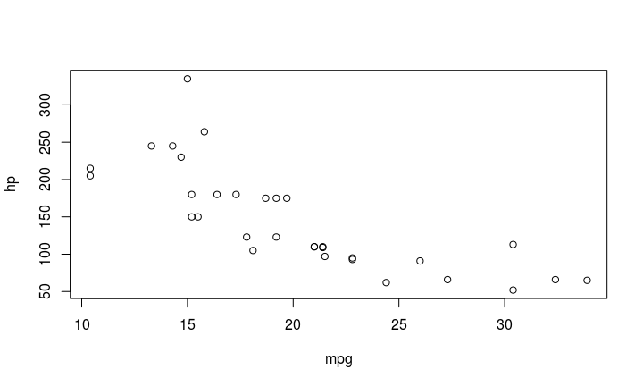

```
## Empty data.table (0 rows) of 1 col: V1
```

```r
mtcarsDT[, .(plot(mpg, hp))]
```

## Grouping with *by*

Again, use `.()` for multiple variables (or just us it always)

```r
mtcarsDT[, .(mean_mpg = mean(mpg)), by = .(cyl)]
```

```
##    cyl mean_mpg
## 1:   6 19.74286
## 2:   4 26.66364
## 3:   8 15.10000
```

We can use functions in *by*:

```r
mtcarsDT[, .(mean_mpg = mean(mpg)),
             by = .(tons = round(wt * 0.4536))]
```

```
##    tons mean_mpg
## 1:    1 24.51250
## 2:    2 15.66875
```

## Grouping with *by*

*Nice to know*: `.N` is a shortcut for `nrow()`

```r
mtcarsDT[, .(Nobs = .N),
         by = .(cyl, am)]
```

```
##    cyl am Nobs
## 1:   6  1    3
## 2:   4  1    8
## 3:   6  0    4
## 4:   8  0   12
## 5:   4  0    3
## 6:   8  1    2
```

## And now, everything together

```r
mtcarsDT[mpg >= 20,
         .(AvgHP = mean(hp),
           "MinWT(kg)" = min(wt*453.6)),
         by = .(cyl, under5gears = gear < 5)]
```

```
##    cyl under5gears     AvgHP MinWT(kg)
## 1:   6        TRUE 110.00000 1188.4320
## 2:   4        TRUE  78.33333  732.5640
## 3:   4       FALSE 102.00000  686.2968
```

## Fast search with *keys*

- *keys* are set as one (or more) columns in a dataset
- The dataset is always sorted (ascending) by *keys*
- *keys* do *not* need to be unique
- (Don't think about these like primary keys in SQL)

```r
setkeyv(mtcarsDT, "cyl")
head(mtcarsDT)
```

```
##     mpg cyl  disp hp drat    wt  qsec vs am gear carb
## 1: 22.8   4 108.0 93 3.85 2.320 18.61  1  1    4    1
## 2: 24.4   4 146.7 62 3.69 3.190 20.00  1  0    4    2
## 3: 22.8   4 140.8 95 3.92 3.150 22.90  1  0    4    2
## 4: 32.4   4  78.7 66 4.08 2.200 19.47  1  1    4    1
## 5: 30.4   4  75.7 52 4.93 1.615 18.52  1  1    4    2
## 6: 33.9   4  71.1 65 4.22 1.835 19.90  1  1    4    1
```

## Fast search with *keys*

We can quickly filter for key values:

```r
mtcarsDT[.(6)]
```

```
##     mpg cyl  disp  hp drat    wt  qsec vs am gear carb
## 1: 21.0   6 160.0 110 3.90 2.620 16.46  0  1    4    4
## 2: 21.0   6 160.0 110 3.90 2.875 17.02  0  1    4    4
## 3: 21.4   6 258.0 110 3.08 3.215 19.44  1  0    3    1
## 4: 18.1   6 225.0 105 2.76 3.460 20.22  1  0    3    1
## 5: 19.2   6 167.6 123 3.92 3.440 18.30  1  0    4    4
## 6: 17.8   6 167.6 123 3.92 3.440 18.90  1  0    4    4
## 7: 19.7   6 145.0 175 3.62 2.770 15.50  0  1    5    6
```

## Fast search with *keys*

If multiple keys are set, they can be queried together:

```r
setkeyv(mtcarsDT, c("cyl", "carb"))
mtcarsDT[.(6, 4)]
```

```
##     mpg cyl  disp  hp drat    wt  qsec vs am gear carb
## 1: 21.0   6 160.0 110 3.90 2.620 16.46  0  1    4    4
## 2: 21.0   6 160.0 110 3.90 2.875 17.02  0  1    4    4
## 3: 19.2   6 167.6 123 3.92 3.440 18.30  1  0    4    4
## 4: 17.8   6 167.6 123 3.92 3.440 18.90  1  0    4    4
```

## Fast search with *keys*

Multiple key values of one key can be selected with a vector `c()`

```r
mtcarsDT[.(c(6,4), 1)]
```

```
##     mpg cyl  disp  hp drat    wt  qsec vs am gear carb
## 1: 21.4   6 258.0 110 3.08 3.215 19.44  1  0    3    1
## 2: 18.1   6 225.0 105 2.76 3.460 20.22  1  0    3    1
## 3: 22.8   4 108.0  93 3.85 2.320 18.61  1  1    4    1
## 4: 32.4   4  78.7  66 4.08 2.200 19.47  1  1    4    1
## 5: 33.9   4  71.1  65 4.22 1.835 19.90  1  1    4    1
## 6: 21.5   4 120.1  97 3.70 2.465 20.01  1  0    3    1
## 7: 27.3   4  79.0  66 4.08 1.935 18.90  1  1    4    1
```

## Define variables `:=`

Variables can directly be added, changed or deleted in the *j* part:

```r
#new variable - weight in kg
mtcarsDT[, wt_kg := wt * 0.4536]

#changed variable - weight with only 2 digits
mtcarsDT[, wt_kg := round(wt_kg, 2)]

#delete variable - remove weight in kg
mtcarsDT[, wt_kg := NULL]
```

## Define variables `:=`

*Warning*: `:=` is modifying *by reference*, which means:

```r
mtcarsDT[, wt_kg := wt * 45.36]
```

Changes the dataset `mtcarsDT`!

A new assignment via `<-` or `=` is *not* enough to preserve the original state of a dataset, you have to to use `copy()` if you want an actual copy.

## Define variables `:=`

```r
ncol(mtcarsDT)
```

```
## [1] 12
```

```r
mtcarsDT2 = mtcarsDT
mtcarsDT2[, wt_kg := NULL]
ncol(mtcarsDT)
```

```
## [1] 11
```

*wt_kg* was removed in `mtcarsDT` as well!

## Define variables `:=`

```r
mtcarsDT[, wt_kg := wt * 45.36]
ncol(mtcarsDT)
```

```
## [1] 12
```

```r
mtcarsDT2 <- copy(mtcarsDT)
mtcarsDT2[, wt_kg := NULL]
ncol(mtcarsDT)
```

```
## [1] 12
```

*But*:

```
A new referenced dataset does not need additional memory!
```

## Fast data import with `fread`

*data.table* offers with `fread()` a function to read in large (tabular) data extremly efficient.

No benchmark but you can find a million SO:

http://stackoverflow.com/questions/1727772/quickly-reading-very-large-tables-as-dataframes-in-r http://www.biostat.jhsph.edu/~rpeng/docs/R-large-tables.html https://stat.ethz.ch/pipermail/r-help/2007-August/138315.html http://www.cerebralmastication.com/2009/11/loading-big-data-into-r/ http://stackoverflow.com/questions/9061736/faster-than-scan-with-rcpp http://stackoverflow.com/questions/415515/how-can-i-read-and-manipulate-csv-file-data-in-c http://stackoverflow.com/questions/9352887/strategies-for-reading-in-csv-files-in-pieces http://stackoverflow.com/questions/11782084/reading-in-large-text-files-in-r http://stackoverflow.com/questions/45972/mmap-vs-reading-blocks http://stackoverflow.com/questions/258091/when-should-i-use-mmap-for-file-access http://stackoverflow.com/a/9818473/403310 http://stackoverflow.com/questions/9608950/reading-huge-files-using-memory-mapped-files …

## Transforming data with `reshape2`

`reshape2` is a package for efficient data transformation

Two of the most important function for us are `melt` and `dcast`

*wide* -> *long* : `melt`

*long* -> *wide* : `dcast`

## `reshape2`: `melt`

```r
wd <- data.frame(person = 1:3,
                 weight = round(runif(3, min = 60, max = 90)),
                 size = round(runif(3, min = 160, max = 190)))
wd
```

```
##   person weight size
## 1      1     68  185
## 2      2     82  185
## 3      3     79  176
```

`wd` is in *wide* format!

## `reshape2`: `melt`

```r
wd_long <- melt(wd, id = "person")
wd_long
```

```
##   person variable value
## 1      1   weight    68
## 2      2   weight    82
## 3      3   weight    79
## 4      1     size   185
## 5      2     size   185
## 6      3     size   176
```

Die column *variable* can be set with `variable.name =`.

## `reshape2`: `dcast`

```r
wd_wide <- dcast(wd_long, person ~ variable)
wd_wide
```

```
##   person weight size
## 1      1     68  185
## 2      2     82  185
## 3      3     79  176
```

```r
all.equal(wd_wide, wd)
```

```
## [1] TRUE
```

## `reshape2` for *data.table*

So why did we talk about `reshape2`?

`melt` and `dcast` are both implemented for *data.table*s!

*Warning*: `reshape` from *base* R always returns a *data.frame*!

## JOINing *data.tables*

| JOIN | *data.frame* | *data.table* |
| --- | --- | --- |
| INNER | `merge(X, Y, all = FALSE)` | `X[Y, nomatch = 0]` |
| LEFT OUTER | `merge(X, Y, all.x = TRUE)` | `Y[X]` |
| RIGHT OUTER | `merge(X, Y, all.y = TRUE)` | `X[Y]` |
| FULL OUTER | `merge(X, Y, all = TRUE)` | - |

`merge()` Works for for *data.table* as well (required for a FULL OUTER JOIN)

## The *most important* functionality

```r
data.table(x = rnorm(1000), y = rnorm(1000))
```

```
##                 x           y
##    1: -1.49242244  0.24930565
##    2:  0.71102216  1.54626269
##    3:  0.59304250 -0.61170108
##    4: -0.33275791  1.23692176
##    5:  0.11523060  0.27698127
##   ---
##  996:  1.59618365  0.99917030
##  997:  0.18437767 -0.52893413
##  998: -0.89915921 -0.03359452
##  999: -0.03858597  2.10844793
## 1000:  0.73492446  0.76277208
```

`print` function that doesn't break R for large datasets!

## Summary

- Filter rows in *i*
  - Set *key* for even faster filtering
- Do arbitrary calculations in *j*
  - Always wrap in `.()`
  - Known *data.frame* syntax only works with `with = FALSE`
- Grouping with *by*
  - Again, wrap in `.()`
  - Functions can be used as well
- Define, update and delete variables with `:=`
  - Remember that all this is done *by reference*
- Use `melt` and `dcast` instead of `reshape`
- JOINS can be done with a minimal syntax

## What else?

This talk mainly focuses on the basic syntax of `data.table`s.

There are some more advanced features:

- ordered JOINS (rolling forwards, backwards, …)
- overlapping range JOINS [?](https://github.com/Rdatatable/data.table/wiki/talks/EARL2014_OverlapRangeJoin_Arun.pdf)
- Chaining of multiple queries `DT[][]`
- Customize queries with `mult` and `nomatch`
- … (probably more stuff I have no idea about)

## Resources

- https://cran.r-project.org/web/packages/data.table/
- Vignetten: [1](https://cran.r-project.org/web/packages/data.table/vignettes/datatable-intro-vignette.html), [2](https://cran.r-project.org/web/packages/data.table/vignettes/datatable-keys-fast-subset.html), [3](https://cran.r-project.org/web/packages/data.table/vignettes/datatable-reference-semantics.html), [4](https://cran.r-project.org/web/packages/data.table/vignettes/datatable-reshape.html)
- [Cheat Sheet](https://s3.amazonaws.com/assets.datacamp.com/img/blog/data+table+cheat+sheet.pdf)
- Video lectures at https://www.datacamp.com/
  - Only the first session is free :(
  - Most of my examples are "borrowed" from there!
- Talk by Matt Dowle at UseR2014
  - [klick](http://user2014.stat.ucla.edu/files/tutorial_Matt.pdf)

## Alternatives

- `dplyr`: Uses chaining syntax `%>%`
  - https://github.com/lmu-applied-r/2015-dplyr (Applied R Munich)
- SQL or noSQL databases (external)
- Commercial R version: Revolution R / Microsoft R, H2O
- …
- Wait and drink even more coffee
- …
- Suggestions?

## Questions?

Thank you for your attention  
Questions? Remarks? Suggestions?